# Forecasting

Dr. B

Thursday, April 16, 2015

Source: [Forecasting: principles and practice](https://www.otexts.org/book/fpp)

```
## [1] "LC_COLLATE=English_United States.1252;LC_CTYPE=English_United States.1252;LC_MONETARY=English_United States.1252;LC_NUMERIC=C;LC_TIME=English_United States.1252"
```

Forecasting is a common statistical task in business, where it helps to inform decisions about the scheduling of production, transportation and personnel, and provides a guide to long-term strategic planning. Business forecasting is often done poorly, and is frequently confused with planning and goals. They are three different things.

```
Forecasting is about predicting the future as accurately as possible, given all of the information available, including historical data and knowledge of any future events that might impact the forecasts.

Goals are what you would like to have happen. Goals should be linked to forecasts and plans, but this does not always occur. Too often, goals are set without any plan for how to achieve them, and no forecasts for whether they are realistic.

Planning is a response to forecasts and goals. Planning involves determining the appropriate actions that are required to make your forecasts match your goals.
```

Forecasting should be an integral part of the decision-making activities of management, as it can play an important role in many areas of a company. Most organizations require short-term, medium-term and long-term forecasts, depending on the specific application.

```
Short-term forecasts are needed for the scheduling of personnel, production and transportation. As part of the scheduling process, forecasts of demand are often also required.

Medium-term forecasts are needed to determine future resource requirements, in order to purchase raw materials, hire personnel, or buy machinery and equipment.

Long-term forecasts are used in strategic planning. Such decisions must take account of market opportunities, environmental factors and internal resources.
```

### Statistical forecasting

The thing we are trying to forecast is unknown (or we wouldn’t be forecasting it), and so we can think of it as a random variable. For example, the total sales for next month could take a range of possible values, and until we add up the actual sales at the end of the month we don’t know what the value will be. So, until we know the sales for next month, it is a random quantity.

Because next month is relatively close, we usually have a good idea what the likely sales values could be. On the other hand, if we are forecasting the sales for the same month next year, the possible values it could take are much more variable. In most forecasting situations, the variation associated with the thing we are forecasting will shrink as the event approaches. The further ahead we forecast, the more uncertain we are.

When we obtain a forecast, we are estimating the middle of the range of possible values the random variable could take. Very often, a forecast is accompanied by a prediction interval giving a range of values the random variable could take with relatively high probability. For example, a 95% prediction interval contains a range of values which should include the actual future value with probability 95%.

A forecast is always based on some observations. Suppose we denote all the information we have observed as I and we want to forecast yi. We then write yi|I meaning “the random variable yi given what we know in I”. The set of values that this random variable could take, along with their relative probabilities, is known as the “probability distribution” of yi|I. In forecasting, we call this the “forecast distribution”. When we talk about the “forecast”, we usually mean the average value of the forecast distribution, and we put a “hat” over y to show this. Thus, we write the forecast of yi as y^i, meaning the average of the possible values that yi could take given everything we know. Occasionally, we will use y^i to refer to the median (or middle value) of the forecast distribution instead.

### Simple forecasting methods

Some forecasting methods are very simple and surprisingly effective. Sometimes one of these simple methods will be the best forecasting method available. But in many cases, these methods will serve as benchmarks rather than the method of choice. Whatever forecasting methods we develop, they will be compared to these simple methods to ensure that the new method is better than these simple alternatives. If not, the new method is not worth considering.

```r
# Load the data and make it into time series
air <- scan("D:/Data/911air.txt")
airtimeseries <- ts(air, frequency=12, start=c(1990,1))

rail <- scan("D:/Data/911rail.txt")
railtimeseries <- ts(rail, frequency=12, start=c(1990,1))

car <- scan("D:/Data/911car.txt")
cartimeseries <- ts(car, frequency=12, start=c(1990,1))
```

#### Average method

The forecasts of all future values are equal to the mean of the historical data.

```r
# meanf(y, h)
# y contains the time series
# h is the forecast horizon

meanairfcast <- meanf(airtimeseries,12)
meanrailfcast <-meanf(railtimeseries,12)
meancarfcast <- meanf(cartimeseries,12)
```

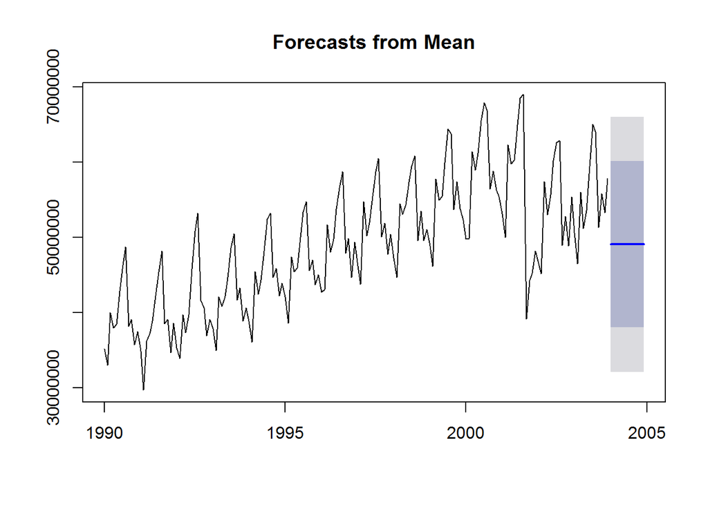

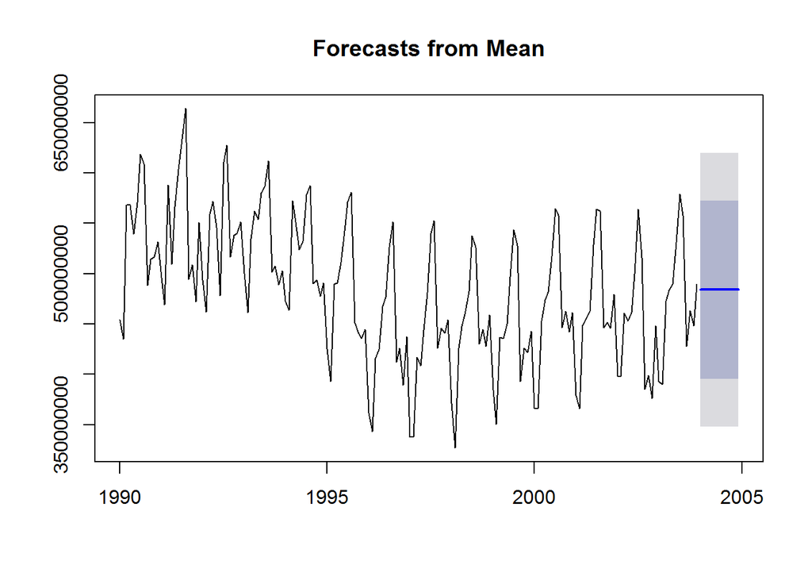

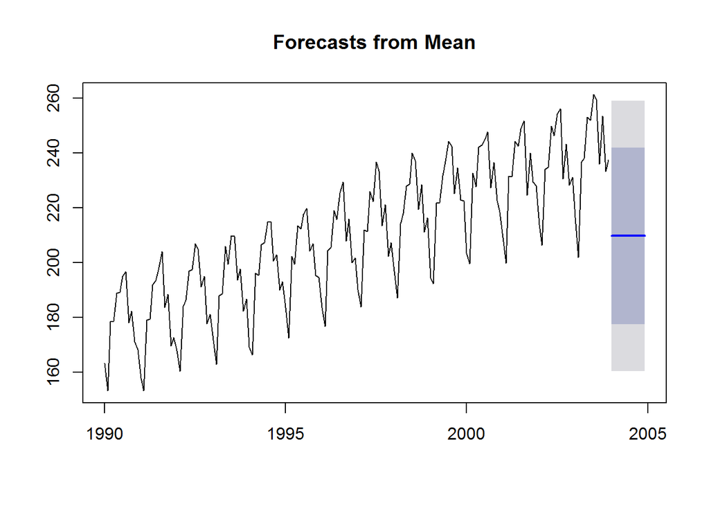

#### Naive Method

This method is only appropriate for time series data. All forecasts are simply set to be the value of the last observation.

```r
# naive(y, h) or rwf(y,h)
# y contains the time series
# h is the forecast horizon

naiveairfcast <- naive(airtimeseries,12)
naiverailfcast <-naive(railtimeseries,12)
naivecarfcast <- naive(cartimeseries,12)
```

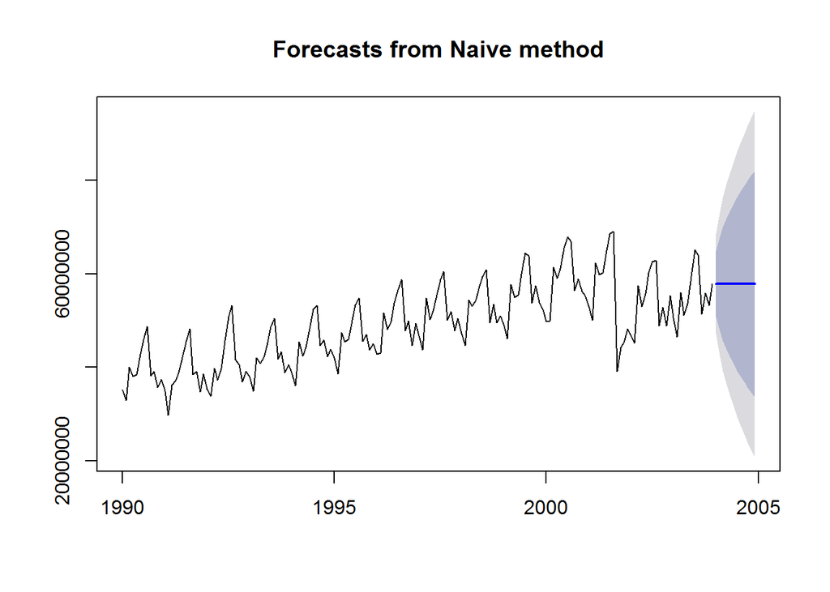

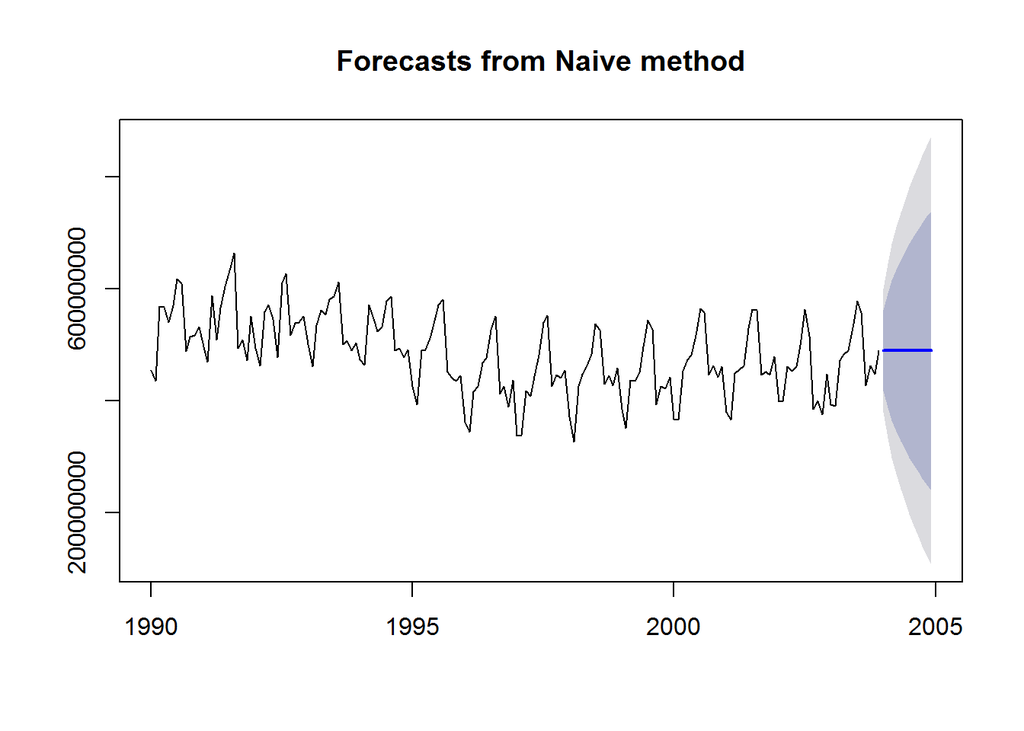

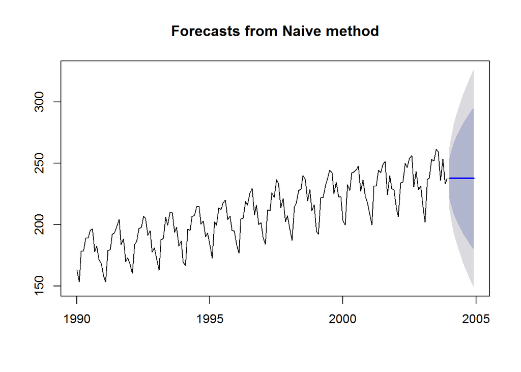

#### Seasonal naive method

A similar method is useful for highly seasonal data. In this case, we set each forecast to be equal to the last observed value from the same season of the year (e.g., the same month of the previous year).

```r
# naive(y, h) or rwf(y,h)
# y contains the time series
# h is the forecast horizon

snaiveairfcast <- snaive(airtimeseries,12)
snaiverailfcast <-snaive(railtimeseries,12)
snaivecarfcast <- snaive(cartimeseries,12)
```

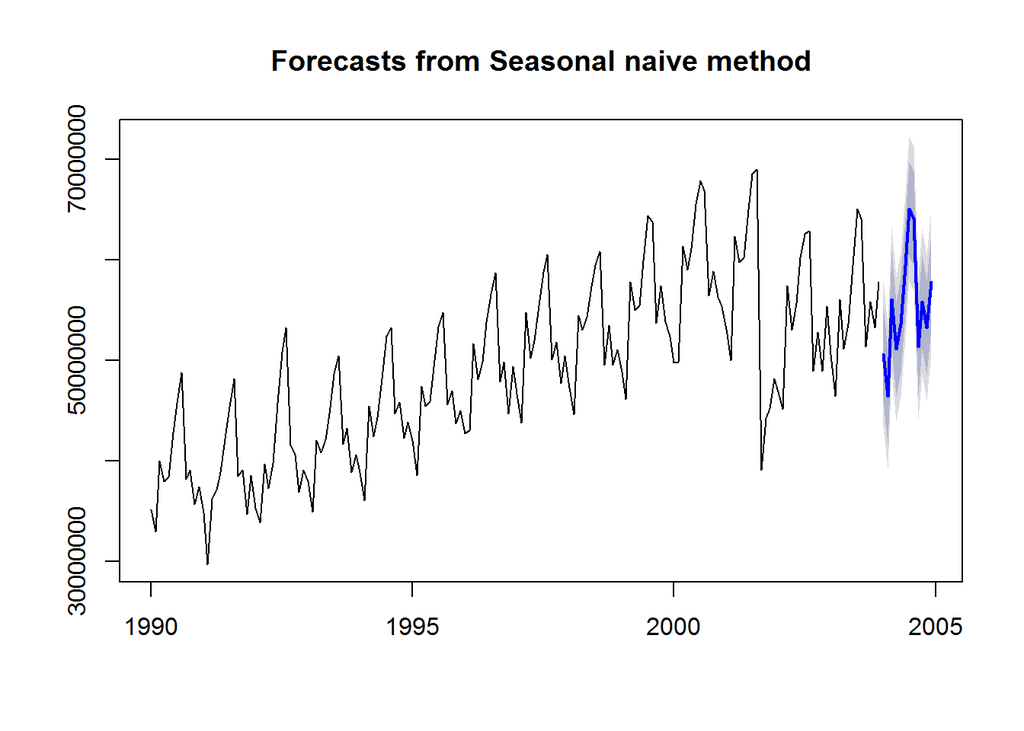

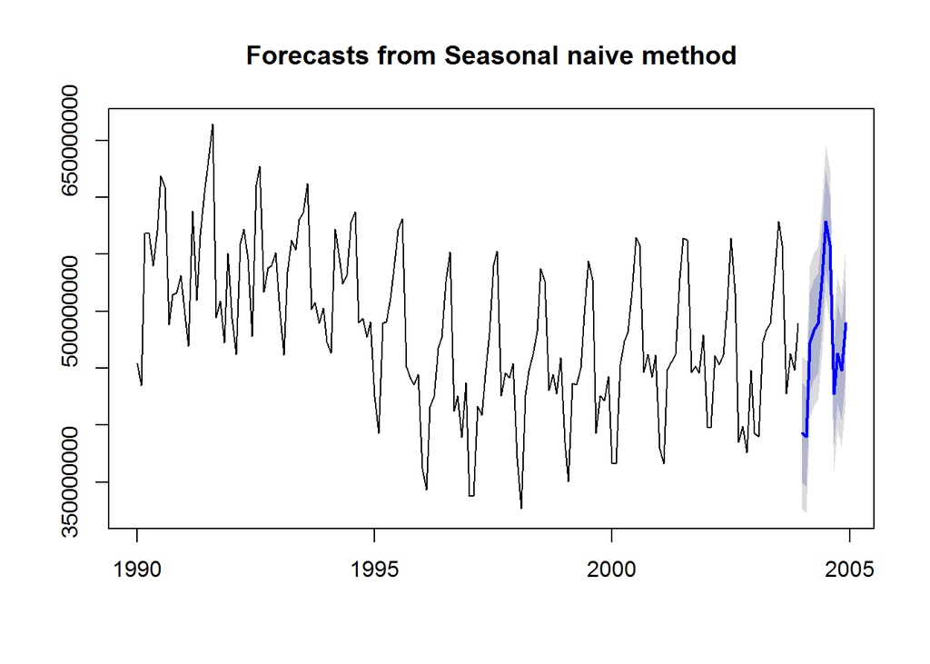

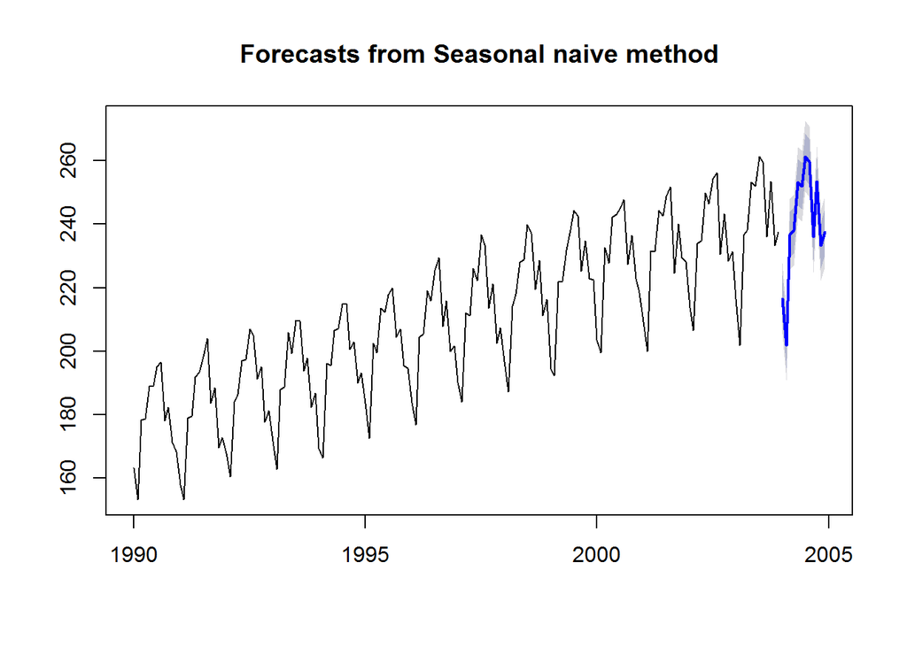

#### Drift method

A variation on the naïve method is to allow the forecasts to increase or decrease over time, where the amount of change over time (called the drift) is set to be the average change seen in the historical data. This is equivalent to drawing a line between the first and last observation, and extrapolating it into the future.

```r
#rwf(y,h, drift=TRUE)
# y contains the time series
# h is the forecast horizon

rwfairfcast <- rwf(airtimeseries,12, drift=TRUE)
rwfrailfcast <-rwf(railtimeseries,12, drift=TRUE)
rwfcarfcast <- rwf(cartimeseries,12, drift=TRUE)
```

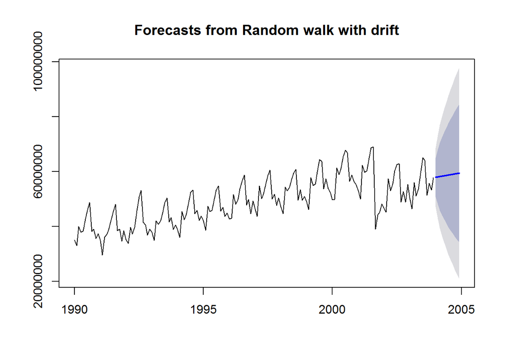

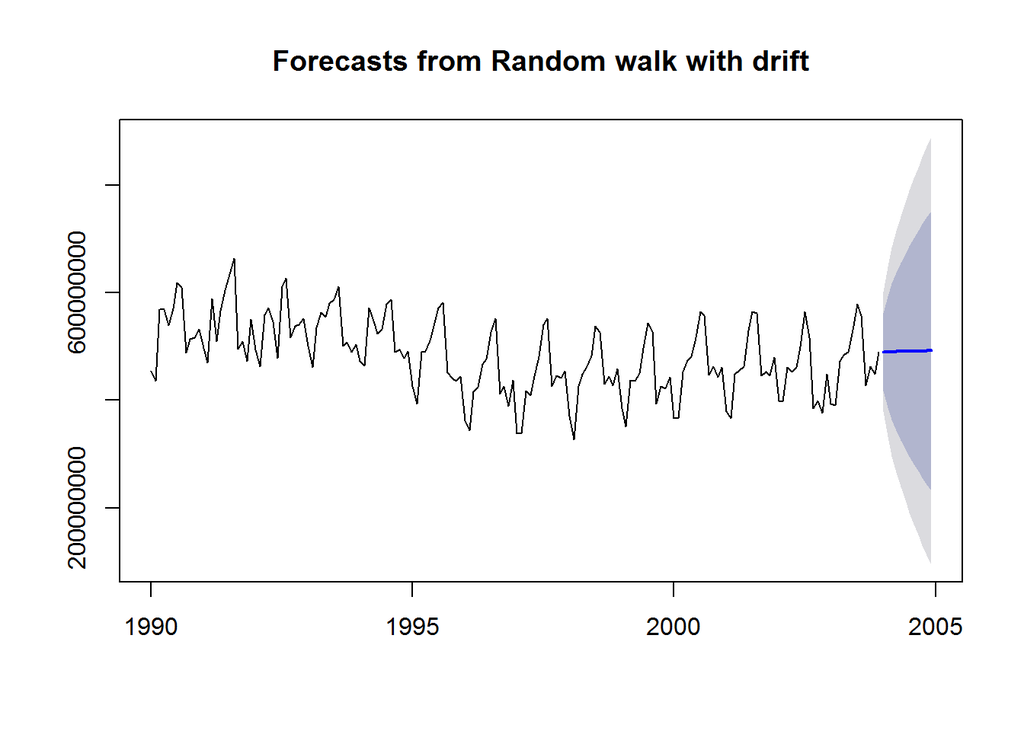

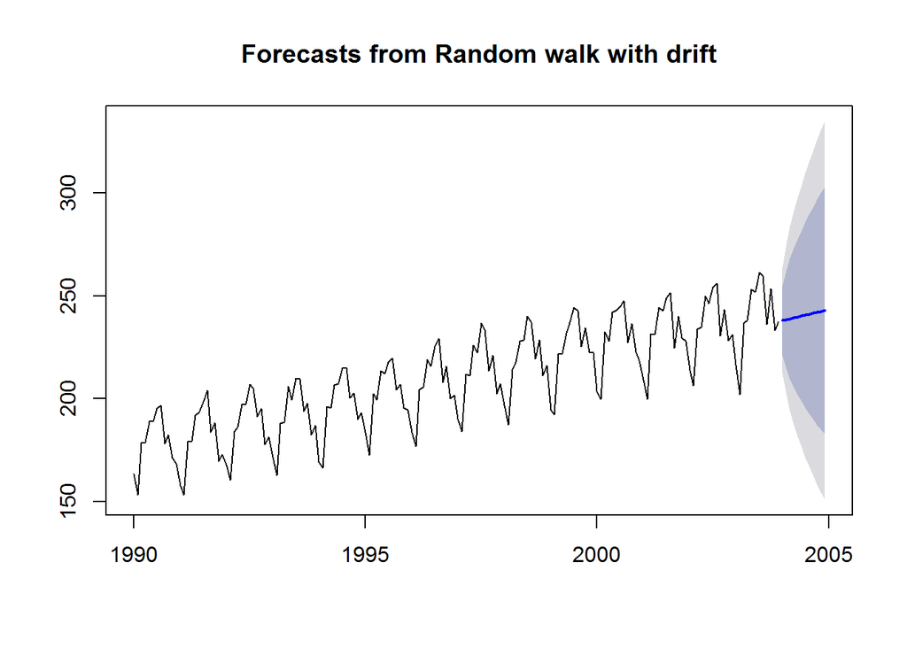

### Other

#### Simple exponential smoothing

he simplest of the exponentially smoothing methods is naturally called “simple exponential smoothing” (SES). In some books, it is called “single exponential smoothing”. This method is suitable for forecasting data with no trend or seasonal pattern.

```r
air2 <- window(airtimeseries,start=1990,end=2004)
```

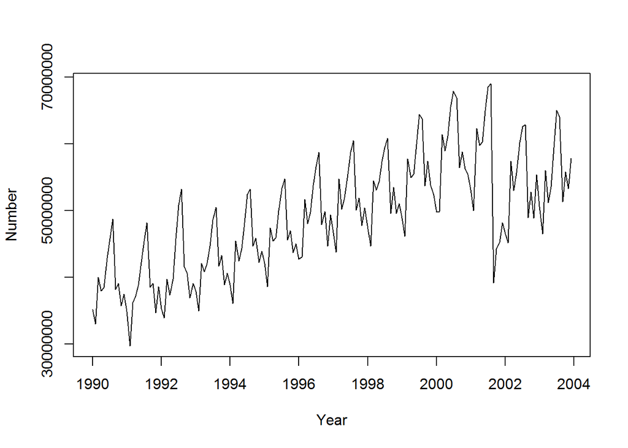

```r
plot(air2, ylab="Number",xlab="Year")
```

Using the naïve method, all forecasts for the future are equal to the last observed value of the series.

Using the average method, all future forecasts are equal to a simple average of the observed data

We often want something between these two extremes. For example it may be sensible to attach larger weights to more recent observations than to observations from the distant past. This is exactly the concept behind simple exponential smoothing. Forecasts are calculated using weighted averages where the weights decrease exponentially as observations come from further in the past — the smallest weights are associated with the oldest observations:

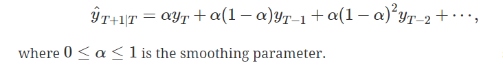

```r
fit1 <- ses(air2, alpha=0.2, initial="simple", h=11)
fit2 <- ses(air2, alpha=0.6, initial="simple", h=11)
fit3 <- ses(air2, h=11)

summary(fit1)
```

```
##
## Forecast method: Simple exponential smoothing
##
## Model Information:
##
##
## Call:
##  ses(x = air2, h = 11, initial = "simple", alpha = 0.2)
##
##   Smoothing parameters:
##     alpha = 0.2
##
##   Initial states:
##     l = 35153577
##
##   sigma:  5659463
## Error measures:
##                    ME    RMSE     MAE       MPE     MAPE     MASE
## Training set 625248.3 5659463 4740593 0.2039295 9.671286 1.710829
##                   ACF1
## Training set 0.4401958
##
## Forecasts:
##          Point Forecast    Lo 80    Hi 80    Lo 95    Hi 95
## Jan 2004       56161921 48909027 63414815 45069577 67254266
## Feb 2004       56161921 48765391 63558451 44849905 67473937
## Mar 2004       56161921 48624492 63699350 44634419 67689424
## Apr 2004       56161921 48486179 63837663 44422887 67900955
## May 2004       56161921 48350315 63973527 44215101 68108742
## Jun 2004       56161921 48216774 64107069 44010867 68312976
## Jul 2004       56161921 48085440 64238402 43810009 68513833
## Aug 2004       56161921 47956208 64367634 43612366 68711476
## Sep 2004       56161921 47828980 64494862 43417788 68906055
## Oct 2004       56161921 47703666 64620177 43226136 69097707
## Nov 2004       56161921 47580181 64743661 43037282 69286560
```

```r
summary(fit2)
```

```
##
## Forecast method: Simple exponential smoothing
##
## Model Information:
##
##
## Call:
##  ses(x = air2, h = 11, initial = "simple", alpha = 0.6)
##
##   Smoothing parameters:
##     alpha = 0.6
##
##   Initial states:
##     l = 35153577
##
##   sigma:  5283931
## Error measures:
##                    ME    RMSE     MAE        MPE     MAPE     MASE
## Training set 210815.4 5283931 4038673 -0.3493441 8.401836 1.457513
##                   ACF1
## Training set 0.1224782
##
## Forecasts:
##          Point Forecast    Lo 80    Hi 80    Lo 95    Hi 95
## Jan 2004       56403766 49632137 63175396 46047452 66760080
## Feb 2004       56403766 48506757 64300776 44326333 68481200
## Mar 2004       56403766 47522857 65284676 42821588 69985945
## Apr 2004       56403766 46637583 66169950 41467678 71339855
## May 2004       56403766 45826143 66981390 40226687 72580846
## Jun 2004       56403766 45072663 67734870 39074339 73733194
## Jul 2004       56403766 44366254 68441279 37993980 74813553
## Aug 2004       56403766 43699063 69108470 36973599 75833934
## Sep 2004       56403766 43065203 69742330 36004194 76803339
## Oct 2004       56403766 42460127 70347405 35078811 77728722
## Nov 2004       56403766 41880239 70927294 34191947 78615585
```

```r
summary(fit3)
```

```
##
## Forecast method: Simple exponential smoothing
##
## Model Information:
## ETS(A,N,N)
##
## Call:
##  ses(x = air2, h = 11)
##
##   Smoothing parameters:
##     alpha = 0.7133
##
##   Initial states:
##     l = 39909230.8631
##
##   sigma:  5269123
##
##      AIC     AICc      BIC
## 6065.224 6065.297 6071.472
##
## Error measures:
##                    ME    RMSE     MAE        MPE    MAPE     MASE
## Training set 139970.4 5269123 3884289 -0.4617195 8.14493 1.401798
##                    ACF1
## Training set 0.01764549
##
## Forecasts:
##          Point Forecast    Lo 80    Hi 80    Lo 95    Hi 95
## Jan 2004       56681412 49928759 63434064 46354120 67008703
## Feb 2004       56681412 48387101 64975722 43996359 69366464
## Mar 2004       56681412 47090122 66272701 42012799 71350024
## Apr 2004       56681412 45948746 67414077 40267217 73095607
## May 2004       56681412 44917596 68445227 38690208 74672615
## Jun 2004       56681412 43969817 69393006 37240706 76122117
## Jul 2004       56681412 43087961 70274862 35892024 77470799
## Aug 2004       56681412 42259929 71102894 34625658 78737165
## Sep 2004       56681412 41476925 71885898 33428156 79934667
## Oct 2004       56681412 40732315 72630508 32289374 81073449
## Nov 2004       56681412 40020952 73341872 31201437 82161386
```

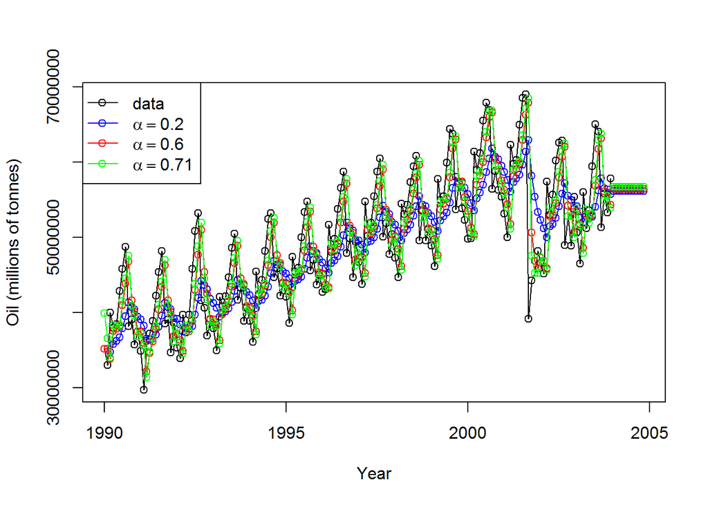

#### Holt’s linear trend method

Holt (1957) extended simple exponential smoothing to allow forecasting of data with a trend. This method involves a forecast equation and two smoothing equations (one for the level and one for the trend):

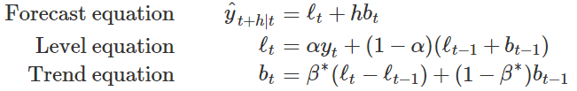

```r
fit1 <- holt(air2, alpha=0.8, beta=0.2, initial="simple", h=11)
fit2 <- holt(air2, alpha=0.8, beta=0.2, initial="simple", exponential=TRUE, h=11)
fit3 <- holt(air2, alpha=0.8, beta=0.2, damped=TRUE, initial="simple", h=11)

# Results for models:
#fit1$model$state
#fitted(fit1)
#fit1$mean
summary(fit1)
```

```
##
## Forecast method: Holt's method
##
## Model Information:
##
##
## Call:
##  holt(x = air2, h = 11, initial = "simple", alpha = 0.8, beta = 0.2)
##
##   Smoothing parameters:
##     alpha = 0.8
##     beta  = 0.2
##
##   Initial states:
##     l = 35153577
##     b = -2188390
##
##   sigma:  5735281
## Error measures:
##                    ME    RMSE     MAE        MPE     MAPE     MASE
## Training set 87840.25 5735281 3863914 -0.3219371 8.143386 1.394445
##                     ACF1
## Training set -0.05535756
##
## Forecasts:
##          Point Forecast    Lo 80     Hi 80     Lo 95     Hi 95
## Jan 2004       57014846 49664788  64364904  45773902  68255789
## Feb 2004       57187602 45706444  68668759  39628687  74746517
## Mar 2004       57360358 41942746  72777969  33781156  80939560
## Apr 2004       57533114 38142329  76923898  27877468  87188760
## May 2004       57705870 34231667  81180072  21805175  93606565
## Jun 2004       57878626 30181485  85575766  15519505 100237747
## Jul 2004       58051382 25979515  90123248   9001695 107101069
## Aug 2004       58224138 21621144  94827131   2244690 114203585
## Sep 2004       58396894 17105527  99688261  -4752803 121546590
## Oct 2004       58569650 12433763 104705537 -11989100 129128400
## Nov 2004       58742406  7607973 109876839 -19460961 136945772
```

```r
summary(fit2)
```

```
##
## Forecast method: Holt's method with exponential trend
##
## Model Information:
##
##
## Call:
##  holt(x = air2, h = 11, initial = "simple", exponential = TRUE,
##
##  Call:
##      alpha = 0.8, beta = 0.2)
##
##   Smoothing parameters:
##     alpha = 0.8
##     beta  = 0.2
##
##   Initial states:
##     l = 35153577
##     b = 0.9377
##
##   sigma:  0.112
## Error measures:
##                     ME    RMSE     MAE        MPE     MAPE     MASE
## Training set -234532.3 5759568 3847852 -0.9870076 8.135157 1.388648
##                     ACF1
## Training set -0.04644445
##
## Forecasts:
##          Point Forecast    Lo 80     Hi 80    Lo 95     Hi 95
## Jan 2004       57284304 49108446  65538326 44839547  69921305
## Feb 2004       57666970 46546043  70014846 41360017  77557340
## Mar 2004       58052192 43691912  74388007 38148767  85751618
## Apr 2004       58439987 40800690  79613856 34158038  95384110
## May 2004       58830372 38177533  86528322 30839241 106842658
## Jun 2004       59223366 35282329  93293284 27232259 119406327
## Jul 2004       59618985 32798770 101215041 23740928 135052485
## Aug 2004       60017246 30304429 110277128 21287804 153607216
## Sep 2004       60418168 27940308 119700115 18800671 172627068
## Oct 2004       60821768 25591541 131321246 16261346 203403939
## Nov 2004       61228064 23257682 142390070 14141411 228142402
```

```r
summary(fit3)
```

```
##
## Forecast method: Damped Holt's method
##
## Model Information:
## ETS(A,Ad,N)
##
## Call:
##  holt(x = air2, h = 11, damped = TRUE, initial = "simple", alpha = 0.8,
##
##  Call:
##      beta = 0.2)
##
##   Smoothing parameters:
##     alpha = 0.8
##     beta  = 0.2
##     phi   = 0.8
##
##   Initial states:
##     l = 35137421.8107
##     b = 867602.3029
##
##   sigma:  5546753
##
##      AIC     AICc      BIC
## 6084.477 6084.623 6093.849
##
## Error measures:
##                    ME    RMSE     MAE        MPE     MAPE     MASE
## Training set 72140.52 5546753 3794162 -0.4101576 7.985911 1.369272
##                    ACF1
## Training set -0.1281839
##
## Forecasts:
##          Point Forecast    Lo 80    Hi 80    Lo 95     Hi 95
## Jan 2004       57042419 49933969 64150868 46170983  67913854
## Feb 2004       57233775 46729266 67738285 41168515  73299036
## Mar 2004       57386861 43898035 70875687 36757481  78016241
## Apr 2004       57509329 41269058 73749600 32671978  82346681
## May 2004       57607304 38787419 76427189 28824774  86389834
## Jun 2004       57685684 36428751 78942617 25176010  90195358
## Jul 2004       57748388 34179163 81317612 21702370  93794406
## Aug 2004       57798551 32028936 83568166 18387326  97209776
## Sep 2004       57838681 29970230 85707133 15217563 100459800
## Oct 2004       57870786 27996201 87745370 12181552 103560019
## Nov 2004       57896469 26100641 89692297  9268946 106523992
```

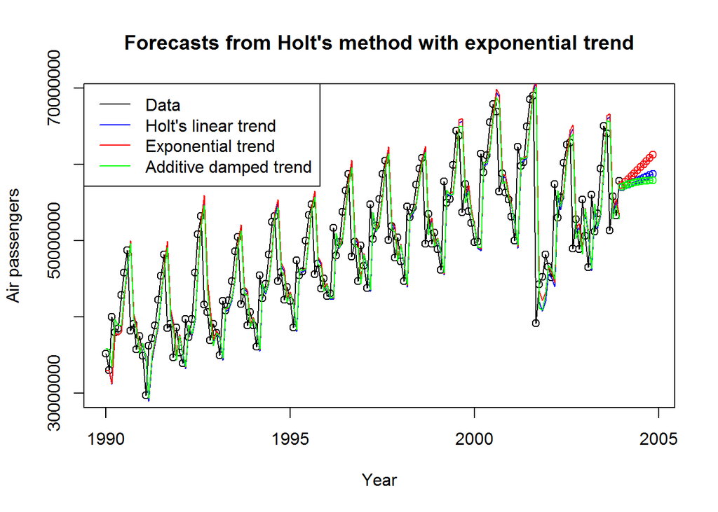

#### Holt-Winters exponential smoothing

If you have a time series that can be described using an additive model with increasing or decreasing trend and seasonality, you can use Holt-Winters exponential smoothing to make short-term forecasts. Holt-Winters exponential smoothing estimates the level, slope, and seasonal component at the current time point.

Smoothing is controlled by three parameters: alpha, beta, and gamma, for the estimates of the level, slope b of the trend component, and the seasonal component, respectively, at the current time point. The parameters alpha, beta and gamma all have values between 0 and 1, and values that are close to 0 mean that relatively little weight is placed on the most recent observations when making forecasts of future values.

```r
logairtimeseries <- log(airtimeseries)
lograiltimeseries <- log(railtimeseries)
logcartimeseries <- log(cartimeseries)

airHWforecast <- HoltWinters(logairtimeseries)
airHWforecast
```

```
## Holt-Winters exponential smoothing with trend and additive seasonal component.
##
## Call:
## HoltWinters(x = logairtimeseries)
##
## Smoothing parameters:
##  alpha: 0.3769939
##  beta : 0.009749497
##  gamma: 0.6536748
##
## Coefficients:
##             [,1]
## a   17.859004663
## b    0.001431308
## s1  -0.064357039
## s2  -0.123190731
## s3   0.090407707
## s4   0.021016944
## s5   0.063612822
## s6   0.145588575
## s7   0.198089699
## s8   0.179179155
## s9  -0.097214206
## s10 -0.020540552
## s11 -0.065931228
## s12  0.011258622
```

```r
railHWforecast <- HoltWinters(lograiltimeseries)
railHWforecast
```

```
## Holt-Winters exponential smoothing with trend and additive seasonal component.
##
## Call:
## HoltWinters(x = lograiltimeseries)
##
## Smoothing parameters:
##  alpha: 0.4853275
##  beta : 0
##  gamma: 0.475178
##
## Coefficients:
##              [,1]
## a   20.0067623393
## b    0.0016164899
## s1  -0.1829968459
## s2  -0.2158248325
## s3  -0.0220586134
## s4  -0.0032391207
## s5   0.0244475016
## s6   0.1092244670
## s7   0.1936684032
## s8   0.1562842823
## s9  -0.0985247112
## s10 -0.0484221808
## s11 -0.0858411831
## s12  0.0004620172
```

```r
carHWforecast <- HoltWinters(logcartimeseries)
carHWforecast
```

```
## Holt-Winters exponential smoothing with trend and additive seasonal component.
##
## Call:
## HoltWinters(x = logcartimeseries)
##
## Smoothing parameters:
##  alpha: 0.1778449
##  beta : 0.01850649
##  gamma: 0.4788611
##
## Coefficients:
##             [,1]
## a    5.486923091
## b    0.001751138
## s1  -0.090944060
## s2  -0.142429460
## s3   0.003737266
## s4   0.004224438
## s5   0.061525419
## s6   0.053948125
## s7   0.083890476
## s8   0.083492252
## s9  -0.015024254
## s10  0.043812312
## s11 -0.027307730
## s12 -0.019733538
```

```r
#carHWforecast$SSE
```

We can plot the original time series as a black line, with the forecasted values as a red line on top of that:

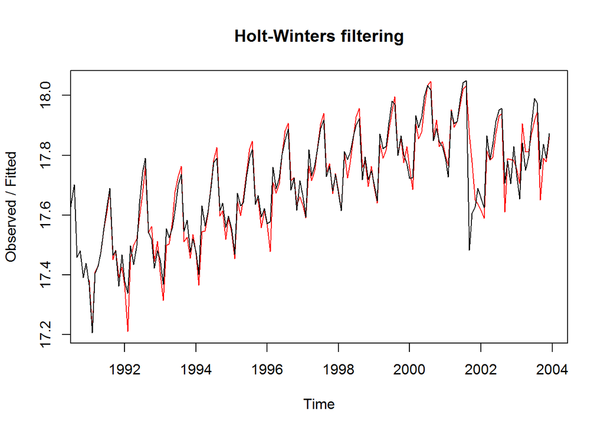

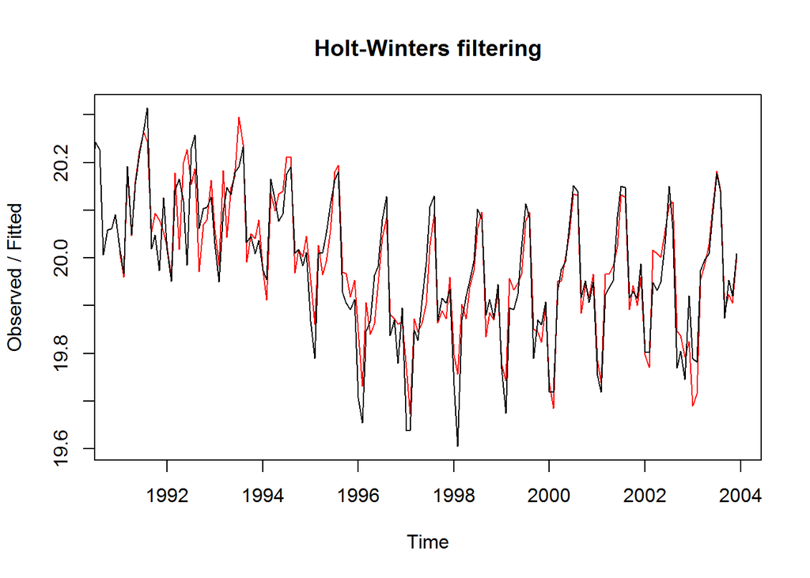

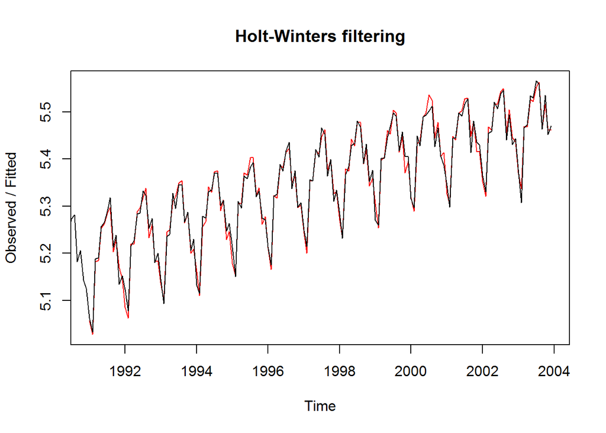

To make forecasts for future times not included in the original time series, we use the “forecast.HoltWinters()” function in the “forecast” package. For example, the original data is from January 1990 to December 2003. If we wanted to make forecasts for January 2004 to December 2007 (48 more months), and plot the forecasts, we would type:

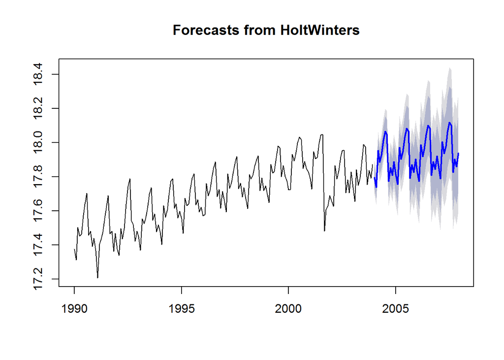

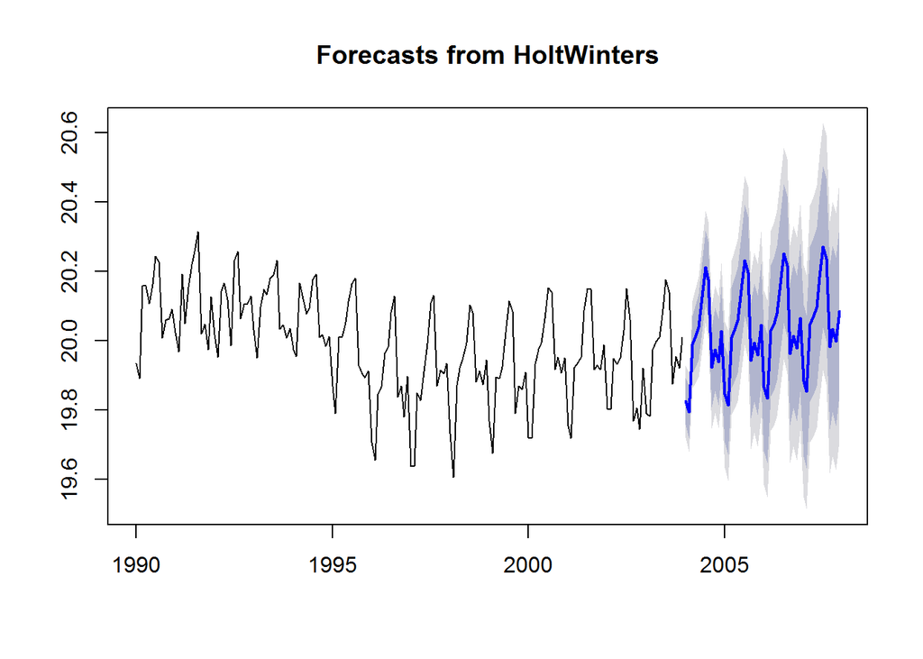

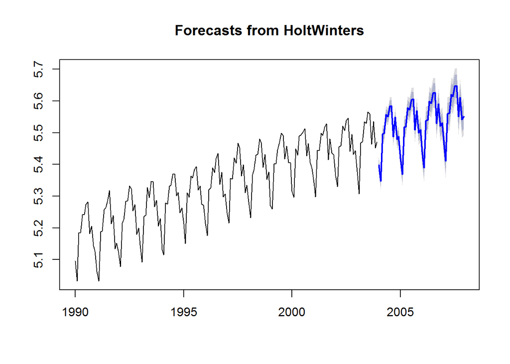

The forecasts are shown as a blue line, and the shaded areas show 80% and 95% prediction intervals.

We can investigate whether the predictive model can be improved upon by checking whether the in-sample forecast errors show non-zero autocorrelations at lags 1-20, by making a correlogram and carrying out the Ljung-Box test:

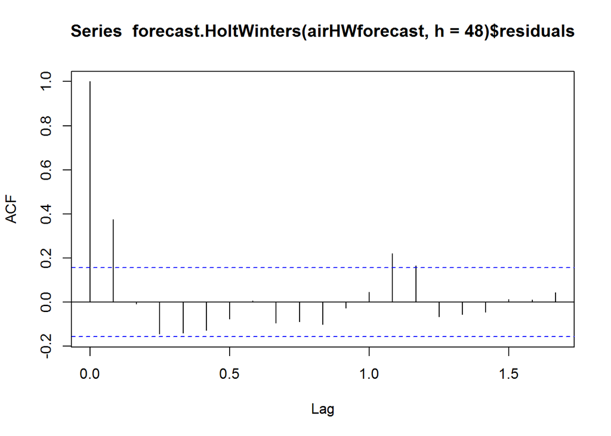

```r
acf(forecast.HoltWinters(airHWforecast, h=48)$residuals, lag.max=20)
```

```r
Box.test(forecast.HoltWinters(airHWforecast, h=48)$residuals, lag=20, type="Ljung-Box")
```

```
##
##  Box-Ljung test
##
## data:  forecast.HoltWinters(airHWforecast, h = 48)$residuals
## X-squared = 52.752, df = 20, p-value = 0.00008838
```

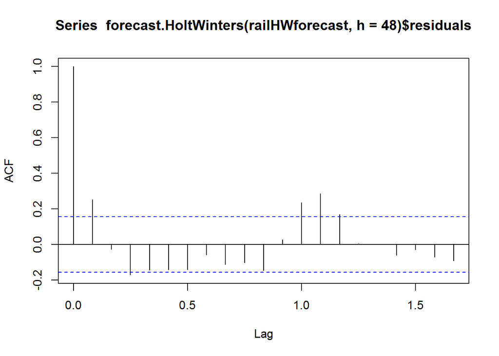

```r
acf(forecast.HoltWinters(railHWforecast, h=48)$residuals, lag.max=20)
```

```r
Box.test(forecast.HoltWinters(railHWforecast, h=48)$residuals, lag=20, type="Ljung-Box")
```

```
##
##  Box-Ljung test
##
## data:  forecast.HoltWinters(railHWforecast, h = 48)$residuals
## X-squared = 64.92, df = 20, p-value = 0.000001202
```

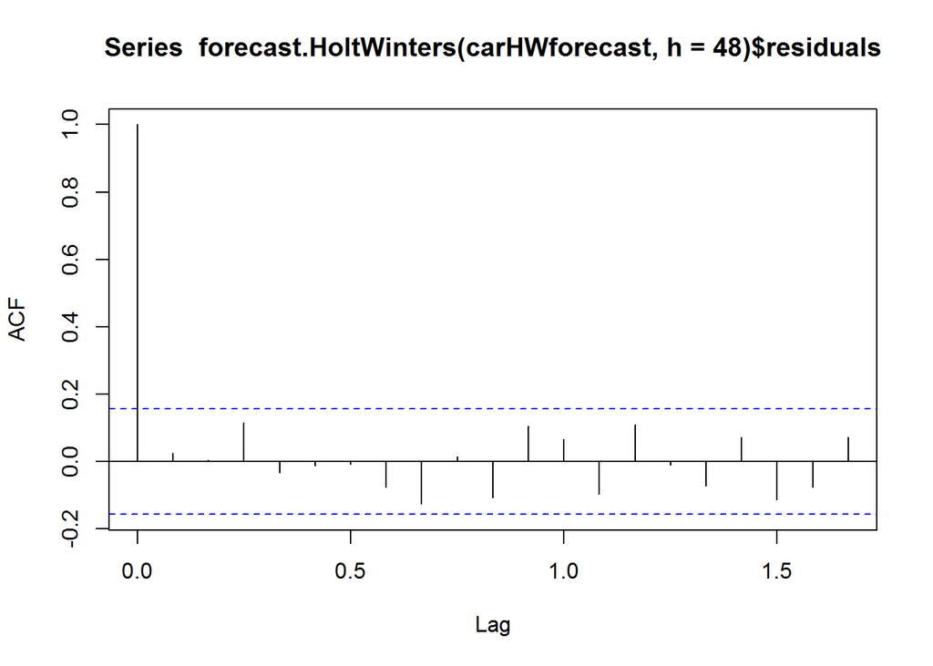

```r
acf(forecast.HoltWinters(carHWforecast, h=48)$residuals, lag.max=20)
```

```r
Box.test(forecast.HoltWinters(carHWforecast, h=48)$residuals, lag=20, type="Ljung-Box")
```

```
##
##  Box-Ljung test
##
## data:  forecast.HoltWinters(carHWforecast, h = 48)$residuals
## X-squared = 20.467, df = 20, p-value = 0.4291
```

Look to see if the correlogram shows that the autocorrelations for the in-sample forecast errors exceed the significance bounds for lags 1-20. Furthermore, if the p-value for Ljung-Box test is > .05, there is little evidence of non-zero autocorrelations at lags 1-20.

We can check whether the forecast errors have constant variance over time, and are normally distributed with mean zero, by making a time plot of the forecast errors and a histogram (with overlaid normal curve):

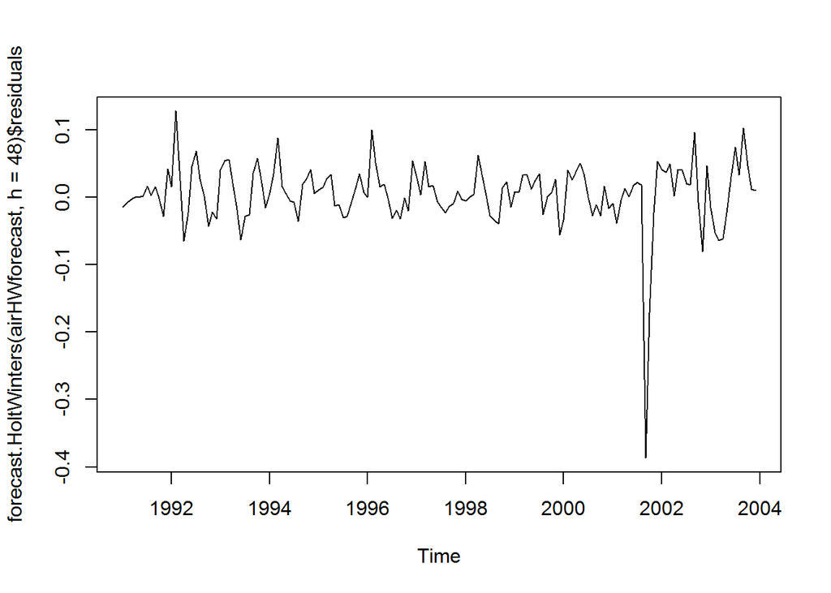

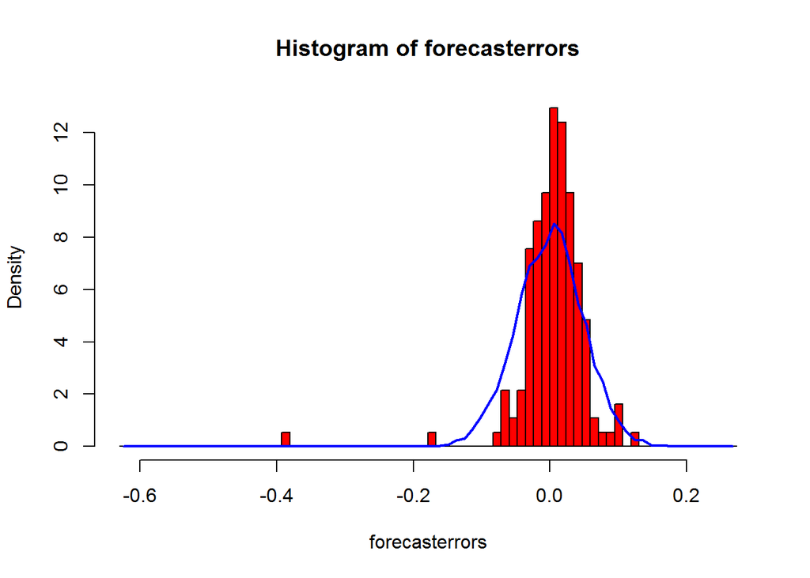

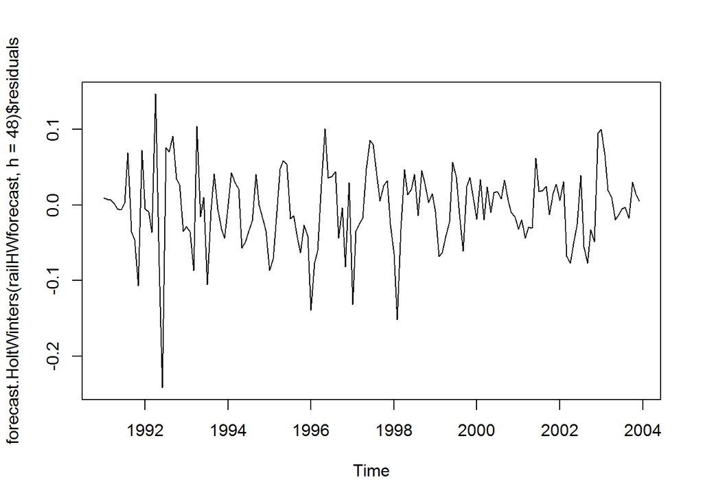

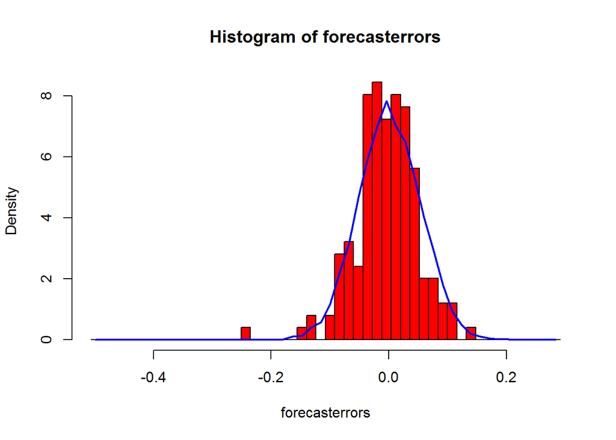

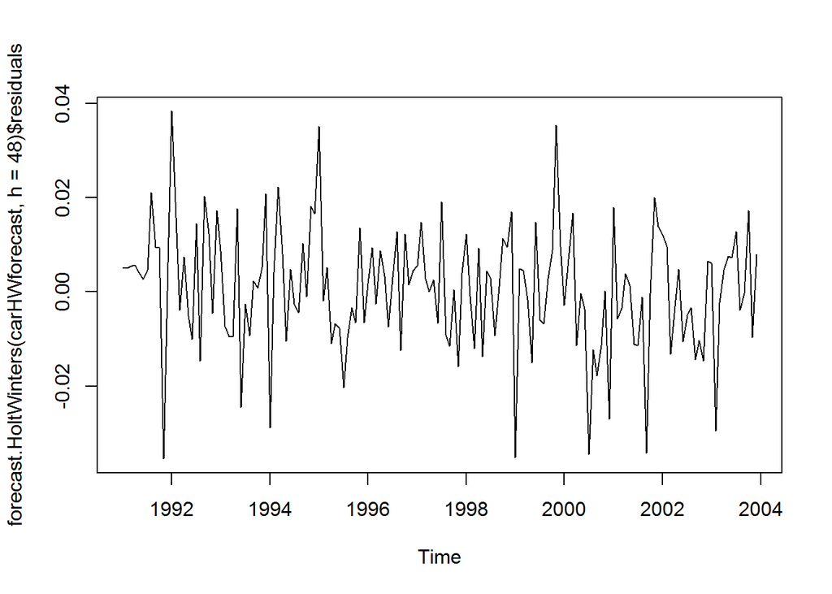

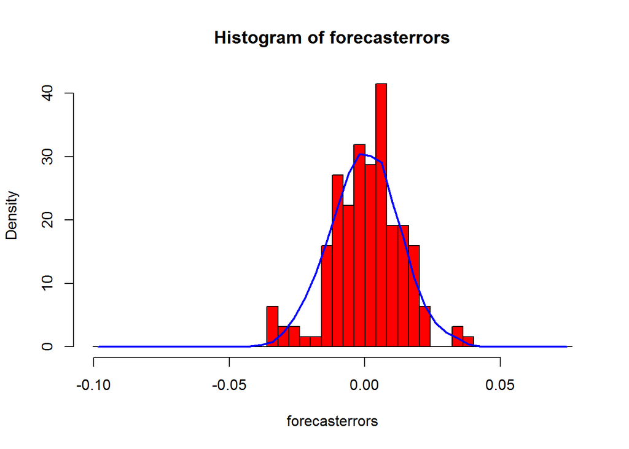

The two most commonly used scale-dependent measures are based on the

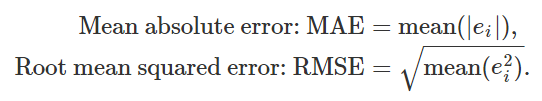

.

When comparing forecast methods on a single data set, the MAE is popular as it is easy to understand and compute.

### Percentage error

Percentage errors have the advantage of being scale-independent, and so are frequently used to compare forecast performance between different data sets.

The most commonly used measure is:

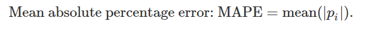

.

Percentage errors assume a meaningful zero. For example, a percentage error makes no sense when measuring the accuracy of temperature forecasts on the Fahrenheit or Celsius scales. Percentage errors also put a heavier penalty on negative errors than on positive errors. This observation led to the use of the so-called “symmetric” MAPE (sMAPE) proposed by Armstrong (1985, p.348), although in general sMAPE should not be used.